# COVID 19 Project

Michael Norton

2023-03-05

## COVID 19 Death and Incident Analysis based on Johns Hopkins COVID 19 data

Lists of US and Global COVID 19 Incidents and Deaths from Time Series

The source data contains daily time series summary tables, including confirmed, deaths and recovered. All data is read in from the daily case report.

Two time series tables are for the US confirmed cases and deaths, reported at the county level. They are named time_series_covid19_confirmed_US.csv, time_series_covid19_deaths_US.csv, respectively.

Two series tables are for the global confirmed cases and deaths. Australia, Canada and China are reported at the province/state level. Dependencies of the Netherlands, the UK, France and Denmark are listed under the province/state level. The US and other countries are at the country level. The tables are renamed time_series_covid19_confirmed_global.csv and time_series_covid19_deaths_global.csv.

## Data Dictionary

| Column Name | Column Description |
| --- | --- |
| Admin2 | County or Administrative District |
| Province/State | Province or State |
| Country/Region | Country or Other Regional District |
| Combined_Key | Province or State AND County or Administrative District |
| date | Date Case and Death Occured |
| cases | Count of reported cases of COVID 19 |
| deaths | Count of reported deaths from COVID 19 |
| UID | Uhnique Identifier |

### Loading Librarys

I am using both tidyverse and lubridate

```r
library(tidyverse)
library(lubridate)
```

##Import Data 1. import up to date files from the target urls into an object in two steps. first, create an object with the common url segment, then upload each of the 4 source csv url segments into a concatenated file, the merge them,

2. Read each of the csv files into a datafreame.
3. view the data using glimpse and head to print lead rows of the table

| Column Name | Column Description |
| --- | --- |
| Admin2 | County or Administrative District |
| Province/State | Province or State |
| Country/Region | Country or Other Regional District |
| Combined_Key | Province or State AND County or Administrative District |
| date | Date Case and Death Occured |
| cases | Count of reported cases of COVID 19 |
| deaths | Count of reported deaths from COVID 19 |
| UID | Uhnique Identifier |

#### Importing the data from the source

```r
url_input <- "https://github.com/CSSEGISandData/COVID-19/raw/master/csse_covid_19_data/csse_covid_19_time_series/"
files_from_url <- c("time_series_covid19_confirmed_US.csv", "time_series_covid19_confirmed_global.csv", "time_series_covid19_deaths_US.csv", "time_series_covid19_deaths_global.csv")
urls <- str_c(url_input, files_from_url)
```

```r
confirmed_US <- read_csv(urls[1])   #reading the cvs files into dataframes
confirmed_global <- read_csv(urls[2])
deaths_US <- read_csv(urls[3])
deaths_global <- read_csv(urls[4])
```

## Wrangle the data into useful dataframes

Here I am pivoting the data to make each date a row instead of a column with the attributes present for each row e,g country, state, cases, deaths etc.

Also Joining the tables so that both cases and deaths are in the same dataframe

This will result in dataframes for US COvid activity and Global US Covid activity by date fpr all reporting entitites, county, state and country

DUring the wrangling, I am removing irrelevant columns, renaming columns to standardize (e.g. get rid of slashes), checking for and treating null values, converting date fields, modifying to factors where I think I may use a value in my model.

I am also engineering new features like deaths per million and cases per million.

Although I am not including them in my knit, I often execute summary, head, tail and glimps functions to assess my dataframes.

```r
us_cases <- confirmed_US %>%
  pivot_longer(cols = -(UID:Combined_Key),  #pivoting the data
    names_to = "date",
    values_to = "cases")%>%
  select(Admin2:cases) %>%
  mutate(date = mdy(date)) %>%    # converting the date field
  select(-c(Lat, Long_))          # removing irrelevant columns
```

```r
us_deaths <- deaths_US %>%
  pivot_longer(cols = -(UID:Population),
    names_to = "date",
    values_to = "cases")%>%
  select(Admin2:cases) %>%
  mutate(date = mdy(date)) %>%
  select(-c(Lat, Long_))
```

```r
US <- us_cases %>%
  full_join(us_deaths)   # joining us cases and deaths into a single dataframe
```

[output not shown]

```r
deaths_global <- deaths_global %>%
  pivot_longer(cols = -c("Province/State", "Country/Region", Lat, Long),
    names_to = "date",
    values_to = "deaths") %>%
  select(-c(Lat, Long))
```

```r
confirmed_global <- confirmed_global %>%
  pivot_longer(cols = -c("Province/State", "Country/Region", Lat, Long),
    names_to = "date",
    values_to = "cases") %>%
  select(-c(Lat, Long))
```

```r
global <- confirmed_global %>%
  full_join(deaths_global) %>%
  rename(Country_Region = "Country/Region",
         Province_State = "Province/State") %>%
  mutate(date = mdy(date))
```

summary(global)

```r
global <- global %>% filter(cases > 0)   # filtering out rows with no cases
```

### Adding population to the global dataframe

Here I am grabbing another file from the source that has population data so that the global file has population data and joining it with the global dataframe

```r
global <- global %>%
  unite("Combined_Key",
        c(Province_State, Country_Region),
        sep = ", ",
        na.rm = TRUE,
        remove = FALSE)
```

```r
Lookup_url<- "https://github.com/CSSEGISandData/COVID-19/raw/master/csse_covid_19_data/UID_ISO_FIPS_LookUp_Table.csv"
```

```r
Lookup <- read_csv(Lookup_url)
global <- global %>%
  left_join(Lookup, by = c("Province_State", "Country_Region")) %>%
  select(-c(UID, FIPS)) %>%
  select(Province_State, Country_Region, date, cases, deaths, Population)
```

## Analysis and Visualizations

Here I am goping to look more deeply into the COVID activity in our neighboring nation of Canada. I would like to see how the COVID cases grew in Canada and also explore whether it was experienced differently in an urban province and in a rural province.

### Filter Canada Data from global Data

Below I am filtering the Canada data from teh global data and removing any rows where I cannot identify the Province.

I am then grouping by Province and State as well as date so each day has a unique and summed up case adn death total for each province. I am going to do slices for Canada as a whole, another summary for all of Canada by provinces and then a summary for the most urban province , Ontario and one of the rural Maritime provinces, Prince Edwards Island.

```r
Canada <- global %>%
  filter(Country_Region == "Canada") %>%   # filtering to only Canada
  filter(Province_State != "NA")           # removing Province Rows with no cases
```

### Summing at the province level with new attribute Deaths per Million

```r
Canadian_Provinces <- Canada %>%
  group_by(Country_Region, Province_State, date) %>%
  summarize(cases = sum(cases), deaths = sum(deaths), Population = sum(Population)) %>%
  mutate(deaths_per_mil = deaths * 1000000/Population) %>%
  select(Country_Region, Province_State, date, cases, deaths, Population) %>%
  ungroup()
```

### Summing for all of Canada with new attribute Deaths per Million

```r
Canada_Summary <- Canadian_Provinces  %>%
   group_by(Country_Region, date) %>%
  summarize(cases = sum(cases), deaths = sum(deaths), Population = sum(Population)) %>%
  mutate(deaths_per_mil = deaths * 1000000/Population) %>%
  select(date, cases, deaths, Population, deaths_per_mil) %>%
  ungroup()
```

### One additional summary with an additional attribute cases per million for a model later

```r
Provincial_Summary <- Canadian_Provinces  %>%
  group_by(Province_State, date) %>%
  summarize(cases = sum(cases), deaths = sum(deaths), Population = sum(Population)) %>%
  mutate(deaths_per_mil = deaths * 1000000/Population) %>%
  mutate(cases_per_mil = cases * 1000000/Population) %>%
  select(date, cases, deaths, Population, deaths_per_mil, Province_State, cases_per_mil) %>%
  ungroup()
```

### Summing for just Ontario and below that for Prince Edward Island

These will support visualizations

```r
Ontario_Summary <- Canadian_Provinces  %>%
  filter(Province_State == "Ontario") %>%
  group_by(Province_State, date) %>%
  summarize(cases = sum(cases), deaths = sum(deaths), Population = sum(Population)) %>%
  mutate(deaths_per_mil = deaths * 1000000/Population) %>%
  select(date, cases, deaths, Population) %>%
  ungroup()
Prince_Edward_Island_Summary <- Canadian_Provinces  %>%
  filter(Province_State == "Prince Edward Island") %>%
  group_by(Province_State, date) %>%
  summarize(cases = sum(cases), deaths = sum(deaths), Population = sum(Population)) %>%
  mutate(deaths_per_mil = deaths * 1000000/Population) %>%
  select(date, cases, deaths, Population) %>%
  ungroup()
```

## Visualizations

Here we will look at a comparison of the COVID case rate and Death rate. The plot will show the growth over time and the differences between case adn death rates

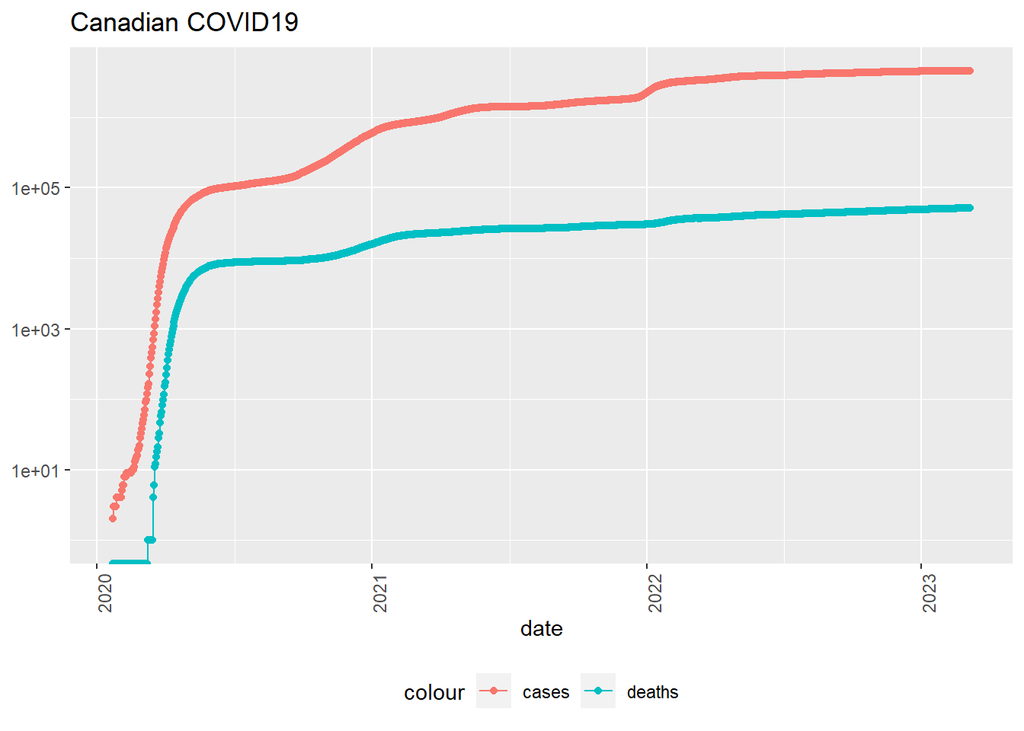

```r
Canada_Summary %>%
  filter(cases > 0) %>%
  ggplot(aes(x = date, y = cases)) +
  geom_line(aes(color = "cases")) +
  geom_point(aes(color = "cases")) +
  geom_line(aes(y = deaths, color = "deaths")) +
  geom_point(aes(y = deaths, color = "deaths")) +
  scale_y_log10() +
  theme(legend.position ="bottom", axis.text.x = element_text(angle = 90)) +
  labs(title = "Canadian COVID19",  y = NULL)
```

## CANADA COVID ACTIVITY Here we see a small lag in deaths as covid cases started but then we see a dramatic spike in early 2020 in both cases and deaths nationwide. In the late spring 2020 both cases and death rates quickly bend and flatting out. Keep in mind that the lines show cunulative cases and deaths and that this scale is logarithmic for ease of viewing the large numbers.

Let’s look at a populous province and then at a rural province

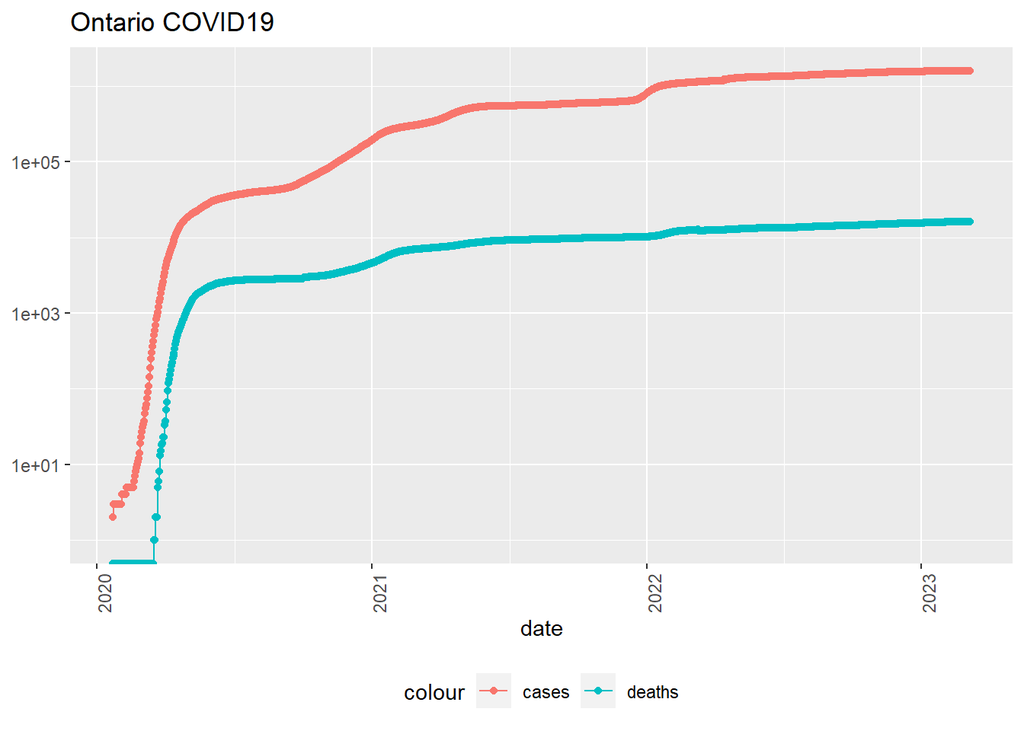

```r
Ontario_Summary %>%
  filter(cases > 0) %>%
  ggplot(aes(x = date, y = cases)) +
  geom_line(aes(color = "cases")) +
  geom_point(aes(color = "cases")) +
  geom_line(aes(y = deaths, color = "deaths")) +
  geom_point(aes(y = deaths, color = "deaths")) +
  scale_y_log10() +
  theme(legend.position ="bottom", axis.text.x = element_text(angle = 90)) +
  labs(title = "Ontario COVID19",  y = NULL)
```

## ONTARIO ACTIVITY

The Ontario plot looks very similar to the Canada Plot. Ontario has the most urban population with Toronto, Hamilton, Windsor and other metropolitan areas.

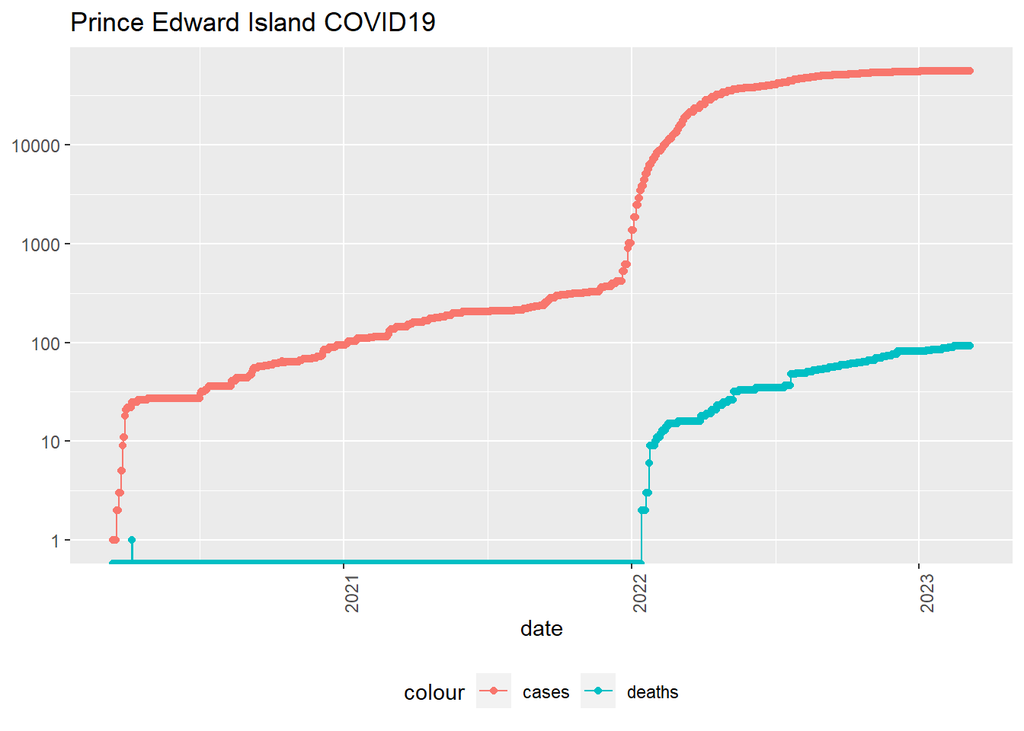

```r
Prince_Edward_Island_Summary %>%
  filter(cases > 0) %>%
  ggplot(aes(x = date, y = cases)) +
  geom_line(aes(color = "cases")) +
  geom_point(aes(color = "cases")) +
  geom_line(aes(y = deaths, color = "deaths")) +
  geom_point(aes(y = deaths, color = "deaths")) +
  scale_y_log10() +
  theme(legend.position ="bottom", axis.text.x = element_text(angle = 90)) +
  labs(title = "Prince Edward Island COVID19",  y = NULL)
```

## PRINCE EDWARD ISLAND ACTIVITY

The PEI plot looks very different than both the Canada and Ontario data. This is a rural Maritime Province in the Far East of Canada. We do see a small spike in 2020 in cases but the deaths are practically non-existent until 2022, two years into the pandemic. Even though total cases are low, one might still expect a proportionate death rate. Now in 2022, We see a spike in both cases and deaths. What changed???? Mobility. Prince Edward Island is a tourist destination of sorts and there is a great possibility that the lifting of a sibstantial lockdown had its effect.

## Create Models

Two questions to be asked. Can I predict the deaths per million based on the province and can i predict the deaths per million based on cases per million. First I need to change the Province into a dactor or categorical to use in the model as an independant variable. Behind the scene models will then one hot encode the Provinces into a binary value so they can be modeled.

```r
Canadian_Provinces$Province_State  <- as.factor(Provincial_Summary$Province_State)
```

```r
model_1 <- lm(deaths_per_mil ~ cases_per_mil, data = Provincial_Summary )
summary(model_1)
```

```
##
## Call:
## lm(formula = deaths_per_mil ~ cases_per_mil, data = Provincial_Summary)
##
## Residuals:
##     Min      1Q  Median      3Q     Max
## -1074.2  -236.1  -166.5   230.6  1291.5
##
## Coefficients:
##                Estimate Std. Error t value Pr(>|t|)
## (Intercept)   2.379e+02  4.609e+00   51.61   <2e-16 ***
## cases_per_mil 3.771e-03  5.227e-05   72.16   <2e-16 ***
## ---
## Signif. codes:  0 '***' 0.001 '**' 0.01 '*' 0.05 '.' 0.1 ' ' 1
##
## Residual standard error: 419.6 on 14009 degrees of freedom
##   (1954 observations deleted due to missingness)
## Multiple R-squared:  0.2709, Adjusted R-squared:  0.2709
## F-statistic:  5206 on 1 and 14009 DF,  p-value: < 2.2e-16
```

Model Analysis

```r
model_2 <- lm(deaths_per_mil ~ Province_State, data = Provincial_Summary )
summary(model_2)
```

```
##
## Call:
## lm(formula = deaths_per_mil ~ Province_State, data = Provincial_Summary)
##
## Residuals:
##      Min       1Q   Median       3Q      Max
## -1292.88  -203.79   -60.73   279.08   948.70
##
## Coefficients:
##                                         Estimate Std. Error t value Pr(>|t|)
## (Intercept)                               601.43      10.92  55.056  < 2e-16
## Province_StateBritish Columbia           -200.90      15.32 -13.115  < 2e-16
## Province_StateManitoba                    255.29      15.47  16.499  < 2e-16
## Province_StateNew Brunswick              -338.71      15.47 -21.900  < 2e-16
## Province_StateNewfoundland and Labrador  -447.14      15.48 -28.884  < 2e-16
## Province_StateNorthwest Territories      -397.65      15.51 -25.645  < 2e-16
## Province_StateNova Scotia                -378.15      15.48 -24.422  < 2e-16
## Province_StateNunavut                    -480.51      16.52 -29.080  < 2e-16
## Province_StateOntario                     -22.72      15.30  -1.485 0.137659
## Province_StatePrince Edward Island       -487.56      15.48 -31.495  < 2e-16
## Province_StateQuebec                      691.44      15.41  44.859  < 2e-16
## Province_StateSaskatchewan                 51.77      15.47   3.346 0.000823
## Province_StateYukon                      -303.79      15.52 -19.573  < 2e-16
##
## (Intercept)                             ***
## Province_StateBritish Columbia          ***
## Province_StateManitoba                  ***
## Province_StateNew Brunswick             ***
## Province_StateNewfoundland and Labrador ***
## Province_StateNorthwest Territories     ***
## Province_StateNova Scotia               ***
## Province_StateNunavut                   ***
## Province_StateOntario
## Province_StatePrince Edward Island      ***
## Province_StateQuebec                    ***
## Province_StateSaskatchewan              ***
## Province_StateYukon                     ***
## ---
## Signif. codes:  0 '***' 0.001 '**' 0.01 '*' 0.05 '.' 0.1 ' ' 1
##
## Residual standard error: 361.6 on 13998 degrees of freedom
##   (1954 observations deleted due to missingness)
## Multiple R-squared:  0.4588, Adjusted R-squared:  0.4584
## F-statistic:   989 on 12 and 13998 DF,  p-value: < 2.2e-16
```

## Conclusions

The data sources are useful to undferstand the pattern of the pandfemic over time and the rate of cases to deaths. They also reveal some differences in rural and urban case rates, especially the difference in the experience over the first 18 months of the pandemic where rural Canadians were far safer. A much richer dataset would have far more value in understanding the features that drive differences in covid activity.

## BIAS

The greatest opportunity in COVID Data Analysis will be in the collection and reporting of the data. There are many questions about how different countries record COVID data. What is a COVID Death. Is there a financial incentive like funding to over report? Or a disincentive? Politically? In tourist areas?Why did Johns Hopkins choose not to include demographic data like age and sex?

The analyst, in this case, myself may also be subject to bias. Why did I choose to look at urban and rural factors. Why did I pick Canada?

We try to be unbiased, but bias is a characteristic that is intrinsic to the human condition.

Data Sources: World Health Organization (WHO): https://www.who.int/

European Centre for Disease Prevention and Control (ECDC): https://www.ecdc.europa.eu/en/geographical-distribution-2019-ncov-cases

DXY.cn. Pneumonia. 2020. http://3g.dxy.cn/newh5/view/pneumonia

US CDC: https://www.cdc.gov/coronavirus/2019-ncov/index.html

BNO News: https://bnonews.com/index.php/2020/02/the-latest-coronavirus-cases/

WorldoMeters: https://www.worldometers.info/coronavirus/

1Point3Arces: https://coronavirus.1point3acres.com/en

COVID Tracking Project: https://covidtracking.com/data.